# Population_structure_T_new_dataset_MQrank

Thomas Francisco

2024-03-14

```r
rm(list = ls())
knitr::opts_chunk$set(cache = FALSE)
library(LEA)
library(ggplot2)
library(pcadapt)
library(vegan)
library(dplyr)
library(RColorBrewer)
library(rnaturalearth)
library(scatterpie)
library(ggplot2)
library(dplyr)
library(writexl)
```

```r
#load metadata
meta_data_vcf <- read.csv("C:/Users/tfrancisco/Documents/Thèse/Data/Espèces/Taxus_baccata/Samples/samples_taxus_baccata_adapcon_gentree.csv",h=T,sep=";",dec=",")

meta_data_pop <- read.csv("C:/Users/tfrancisco/Documents/Thèse/Data/Espèces/Taxus_baccata/Populations/taxus_sample_29pop.csv",h=T,sep=";",dec=",")
```

In this script, we will study the population structure of Taxus baccata Adapcon-Gentree dataset of 8252 SNPs, 452 trees and 4.37% of NAs. We will study the structure using PCA and STRUCTURE software:

```
  1. PCA
```

First, we performed a PCA to study the population structure at the individual scale and population scale. We will also check if the structure of some individuals/populations is not driven by the percentage of missing data. To do so, we will plot the size of the sampled points on the PCA depending on their missing data percentage and the position of the points will depend of their genetic composition. We will use PCADAPT as function to perform the PCA analysis at the Individual level and RDA at the population level (RDA without covariables, then just the PCA is performed, see explanation of Redundancy analysis in the script RDA_candidates detection)

```
  - Individual-level
```

We first perform a screeplot analysis to see how much of the genetic variation is explained by the PCs axis.

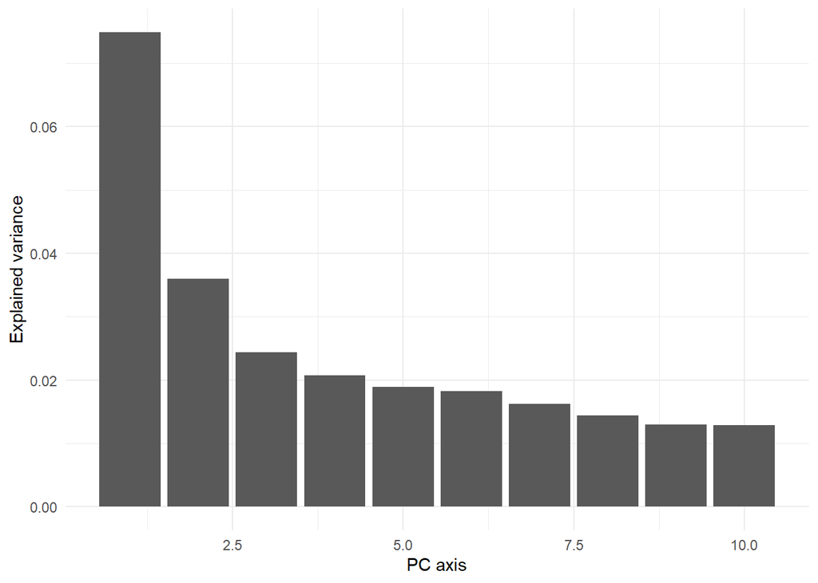

```r
#selection number of axis => screeplot
#initial parameters
load(file = "C:/Users/tfrancisco/Documents/Thèse/Data/Espèces/Taxus_baccata/genetic_new/structure/Dataset_PCA_8252SNP_452IND.Rdata")
gen_data_new <- Dataset_PCA_8252SNP_452IND[,-1]; row.names(gen_data_new) <- Dataset_PCA_8252SNP_452IND$VCF_ID
data <- gen_data_new
k <- 10 #its the number of groups set arbitrary

#function
screeplot_genetic <- function(data,k){

  data_PCa <- data  %>% dplyr::select(-c("na_percentage_indiv")) %>% t() %>% data.frame()
#format for pcadapt
data_pcadapt <- read.pcadapt(data_PCa)

#perform the Pca
Pcadapt_results <-pcadapt(data_pcadapt,K=k,method = "mahalanobis")

# choose the number of axis
 # Create ggplot object
 screeplot_data <- data.frame(
    PC_axis = seq_along(Pcadapt_results$singular.values),
    Explained_variance = Pcadapt_results$singular.values^2
  )

  gg_screeplot <- ggplot(screeplot_data, aes(x = PC_axis, y = Explained_variance)) +
    geom_bar(stat = "identity") +
    labs(x = "PC axis", y = "Explained variance") +
    theme_minimal()

  # Display the screeplot
  gg_screeplot
  print(gg_screeplot)

  #Save
pdf("C:/Users/tfrancisco/Documents/Thèse/Results/species/taxus/STRUCTURE/PCA/screeplot_PCA_indiv_level.pdf");print(gg_screeplot);dev.off()

  return(Pcadapt_results)


}

Pcadapt_object <- screeplot_genetic(data,k)
```

Interpretation: we keep the two first axis as the most important to detect global patterns of population structure.

Now, we can plot the PCA.

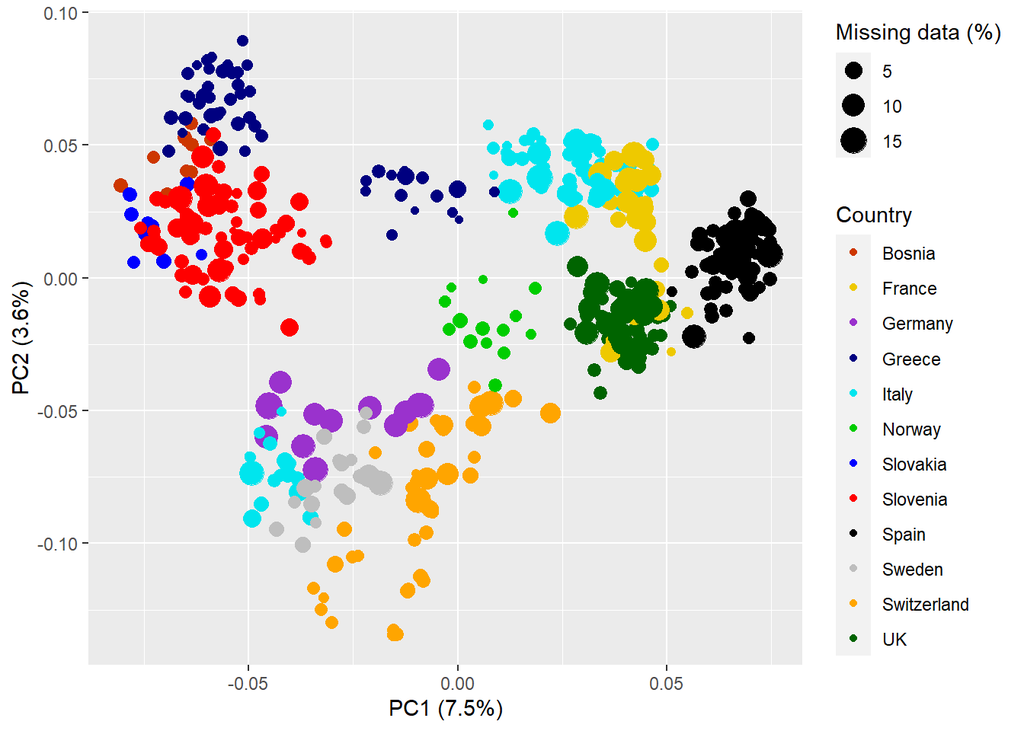

```r
#meta_data
meta_data_vcf_452 <- meta_data_vcf[meta_data_vcf$VCF_ID %in% row.names(gen_data_new),]

#Initial parameters
data <-Pcadapt_object #dataframe coming from the return of the screeplot_genetic function
names <- gen_data_new #initial dataframe
axis <- 2 #number of retained axis based on the screeplot
meta_data <- meta_data_vcf_452#meta data


#color per country

#for loop to do it for multiple PC axis like 1-2 but also 1-3, 2-3 etc
 Pca_genetic <- function(data, names, num_axes, meta_data) {
   #we can create 2 loops that would perform the Pca_function for each combination of axis retained:
  for (i in 1:(num_axes - 1)) { #here, the first loop will select axis between 1 and numb_axis-1 so basically, if we take 3 axis, i will take values of 1 then 2, so PCx will ether be 1 or 2.
    for (j in (i + 1):num_axes) { #here, the second loop within the first one will take the values of j from i +1 to num axis so if num axis=3, we will have j ranging from 2 to 3 when i=1 and j=3 when i =2
      #to summaries, the loops will perform the function for the combination of axis: 1-2,1-3 and 2-3 for 3 retained axis.

      PCx <- i
      PCy <- j

      # Calculate explained variance for chosen PCs
      explained_variance <- data.frame(t(round((data$singular.values[PCx:PCy]^2) * 100, digits = 1)))
      colnames(explained_variance) <- c("PCx", "PCy")

      #store the scores along the retained PC axis in a dataframe
      score_Pca_imputed <- data.frame(data$scores[, c(PCx,PCy)], row.names (names))
      colnames(score_Pca_imputed) <- c(paste0("PC", PCx), paste0("PC", PCy), "VCF_ID")

      # add country, population information
      PCa_df_imputed <- merge(score_Pca_imputed, meta_data, "VCF_ID")

      # genetic PCA
      ggplot_representation <- ggplot() +
        geom_point(data = PCa_df_imputed, aes(PCa_df_imputed[,2],PCa_df_imputed[,3],size = names$na_percentage, color = Country)) +
        scale_colour_manual(name = "Country",
                            values = c("orangered3", "gold2", "darkorchid3", "navyblue", "turquoise2", "green3", "blue", "red", "black", "gray", "orange", "darkgreen")) +
        scale_size(name = "Missing data (%)", breaks = c(0, 5, 10, 14), labels = c("0", "5", "10", "15")) +
        xlab(paste0("PC", PCx, " ", "(", explained_variance$PCx, "%", ")")) +
        ylab(paste0("PC", PCy, " ", "(", explained_variance$PCy, "%", ")"))

      print(ggplot_representation)
#Save
pdf("C:/Users/tfrancisco/Documents/Thèse/Results/species/taxus/STRUCTURE/PCA/PCA_indiv_level_color_countries.pdf");print(ggplot_representation);dev.off()

    }
  }
 }

#run the function
Pca_genetic(data,names,axis,meta_data)
```

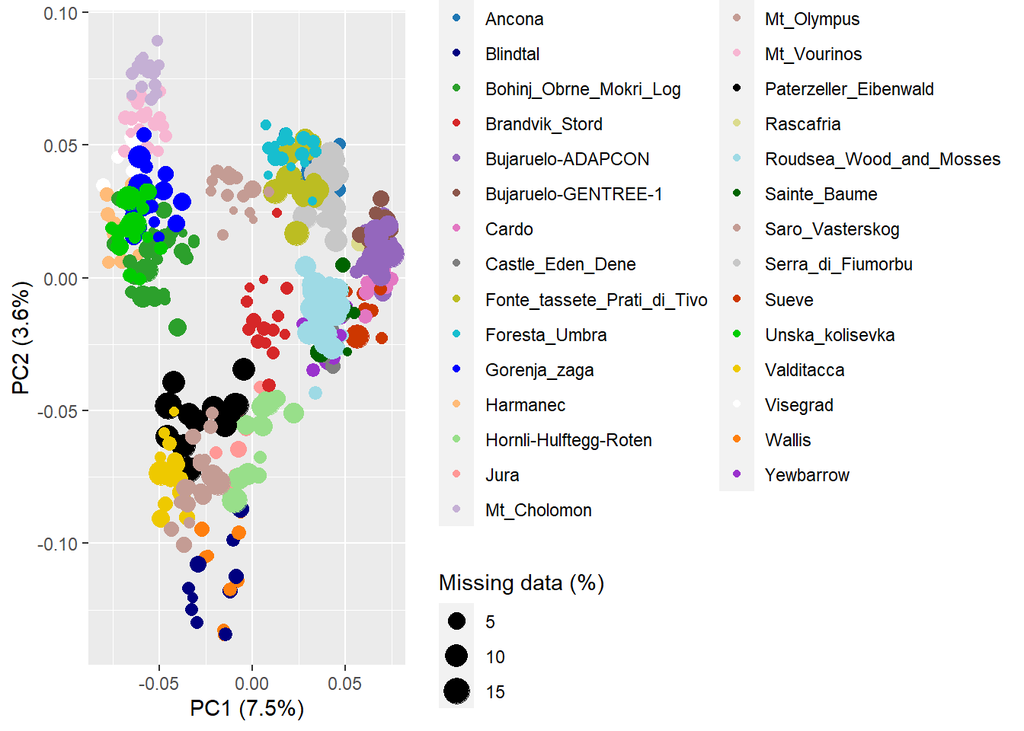

```
- Population-level
```

```r
#color per populations

Pca_genetic <- function(data, names, num_axes, meta_data) {
   #we can create 2 loops that would perform the Pca_function for each combination of axis retained:
  for (i in 1:(num_axes - 1)) { #here, the first loop will select axis between 1 and numb_axis-1 so basically, if we take 3 axis, i will take values of 1 then 2, so PCx will ether be 1 or 2.
    for (j in (i + 1):num_axes) { #here, the second loop within the first one will take the values of j from i +1 to num axis so if num axis=3, we will have j ranging from 2 to 3 when i=1 and j=3 when i =2
      #to summaries, the loops will perform the function for the combination of axis: 1-2,1-3 and 2-3 for 3 retained axis.

      PCx <- i
      PCy <- j

      # Calculate explained variance for chosen PCs
      explained_variance <- data.frame(t(round((data$singular.values[PCx:PCy]^2) * 100, digits = 1)))
      colnames(explained_variance) <- c("PCx", "PCy")

      #store the scores along the retained PC axis in a dataframe
      score_Pca_imputed <- data.frame(data$scores[, c(PCx,PCy)], row.names (names))
      colnames(score_Pca_imputed) <- c(paste0("PC", PCx), paste0("PC", PCy), "VCF_ID")

      # add country, population information
      PCa_df_imputed <- merge(score_Pca_imputed, meta_data, "VCF_ID")

      # genetic PCA
      ggplot_representation <- ggplot() +
        geom_point(data = PCa_df_imputed, aes(PCa_df_imputed[,2],PCa_df_imputed[,3],size = names$na_percentage, color = Population)) +
        scale_color_manual(name="Country", values=c("#1f77b4","navyblue", "#2ca02c", "#d62728", "#9467bd",
            "#8c564b", "#e377c2", "#7f7f7f", "#bcbd22", "#17becf",
            "blue", "#ffbb78", "#98df8a", "#ff9896", "#c5b0d5",
            "#c49c94", "#f7b6d2", "black", "#dbdb8d", "#9edae5",
            "darkgreen", "#c49c94", "#c7c7c7","orangered3","green3" ,
            "gold2","white", "#ff7f0e","darkorchid3" ))+
        scale_size(name = "Missing data (%)", breaks = c(0, 5, 10, 14), labels = c("0", "5", "10", "15")) +
        xlab(paste0("PC", PCx, " ", "(", explained_variance$PCx, "%", ")")) +
        ylab(paste0("PC", PCy, " ", "(", explained_variance$PCy, "%", ")"))

      print(ggplot_representation)

      #Save
pdf("C:/Users/tfrancisco/Documents/Thèse/Results/species/taxus/STRUCTURE/PCA/PCA_indiv_level_color_populations.pdf");print(ggplot_representation);dev.off()
    }
  }
 }



#run the function
Pca_genetic(data,names,axis,meta_data)
```

Finally, we want to calculate the PCA at the population level. Because we’re using the allelic frequencies, we cannot use the PCADAPT function because it cannot handle allelic frequencies. We will use the RDA function who is working in the same way as long as we’re not adding covariates.

First as before, we need to check the number of PCA retained

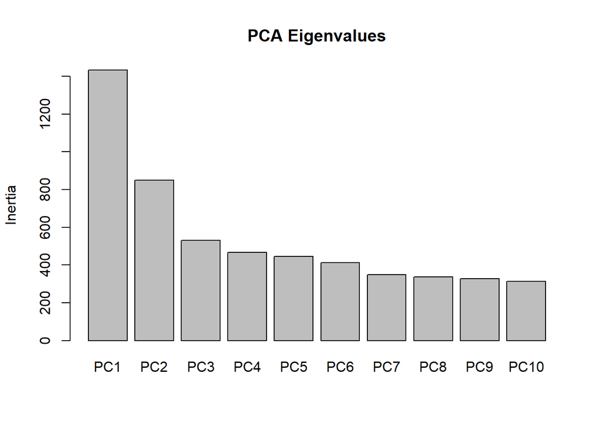

```r
load("C:/Users/tfrancisco/Documents/Thèse/Data/Espèces/Taxus_baccata/genetic_new/data_allelic_frequencies_29pop_adapcon_gentree_475_8616.Rdata")

gen_data_new <- data_allelic_frequencies_29pop_adapcon_gentree_475_8616
data <- gen_data_new
k <- 10

#function
screeplot_genetic <- function(data,k){

#perform the Pca
RDA_structure_genetic<- rda(data, scale=T)
screeplot_graph <- screeplot(RDA_structure_genetic, type = "barplot", npcs=10, main="PCA Eigenvalues")

#Save
pdf("C:/Users/tfrancisco/Documents/Thèse/Results/species/taxus/STRUCTURE/PCA/screeplot_PCA_Pop_level.pdf");screeplot(RDA_structure_genetic, type = "barplot", npcs=10, main="PCA Eigenvalues");dev.off()

}
Pcadapt_object <- screeplot_genetic(data,k)
```

```r
RDA_structure_genetic <- rda(data, scale=T)
```

Interpretation: we keep the two first axis.

We can plot the PCA at the population level.

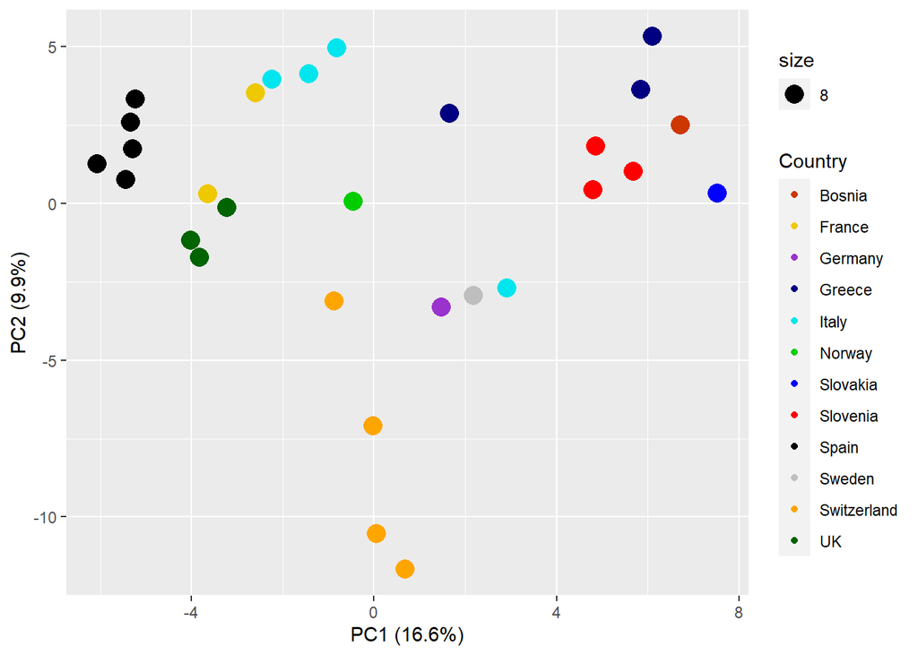

```r
meta_data_vcf_452 <- meta_data_vcf[meta_data_vcf$Population %in% row.names(gen_data_new),]

#Initial parameters
#data <-Pcadapt_object #dataframe coming from the return of the screeplot_genetic function

axis <- 2 #number of retained axis based on the screeplot
meta_data <- meta_data_vcf_452#meta data



#for loop to do it for multiple PC axis like 1-2 but also 1-3, 2-3 etc
 Pca_genetic <- function(data, names, num_axes, meta_data) {
   #we can create 2 loops that would perform the Pca_function for each combination of axis retained:
  for (i in 1:(num_axes - 1)) { #here, the first loop will select axis between 1 and numb_axis-1 so basically, if we take 3 axis, i will take values of 1 then 2, so PCx will ether be 1 or 2.
    for (j in (i + 1):num_axes) { #here, the second loop within the first one will take the values of j from i +1 to num axis so if num axis=3, we will have j ranging from 2 to 3 when i=1 and j=3 when i =2
      #to summaries, the loops will perform the function for the combination of axis: 1-2,1-3 and 2-3 for 3 retained axis.

      PCx <- i
      PCy <- j

      # Calculate explained variance for chosen PCs
      explained_variance <- data.frame(eigenvals(RDA_structure_genetic))
      proportion_variance <- data.frame(t(explained_variance[c(PCx,PCy),] / sum(explained_variance) *100)) %>% round(digit=1)
      colnames(proportion_variance) <- c("PCx", "PCy")

      #store the scores along the retained PC axis in a dataframe
      store_score_rda <- scores(RDA_structure_genetic, axes = c(PCx, PCy),display="sites" ) %>% data.frame(row.names(data))
      colnames(store_score_rda) <- c(paste0("PC", PCx), paste0("PC", PCy), "Population")

      # add country, population information
      PCa_score_T_adapcon_gentree <- merge(store_score_rda, meta_data, "Population") %>% group_by(Population) %>% slice_head(n = 1) %>% ungroup() %>% as.data.frame()  #keep only the first row of each groups



      # genetic PCA
      ggplot_representation <- ggplot() +
        geom_point(data = PCa_score_T_adapcon_gentree, aes(PCa_score_T_adapcon_gentree[,2],PCa_score_T_adapcon_gentree[,3],size=8, color = PCa_score_T_adapcon_gentree$Country)) +
        scale_colour_manual(name = "Country",
                            values = c("orangered3", "gold2", "darkorchid3", "navyblue", "turquoise2", "green3", "blue", "red", "black", "gray", "orange", "darkgreen")) +
        xlab(paste0("PC", PCx, " ", "(", proportion_variance$PCx, "%", ")")) +
        ylab(paste0("PC", PCy, " ", "(", proportion_variance$PCy, "%", ")"))

      print(ggplot_representation)

 #Save
pdf("C:/Users/tfrancisco/Documents/Thèse/Results/species/taxus/STRUCTURE/PCA/PCA_Pop_level.pdf");print(ggplot_representation);dev.off()

      return(PCa_score_T_adapcon_gentree)
    }
  }
 }

#run the function
PCa_score_T_adapcon_gentree<-Pca_genetic(data,names,axis,meta_data)
```

Overall interpretation: Almost the same pattern to what we found with PCA at the individual-level (expected but enable us to see if we did any mistakes during the allelic frequencies calculation or others processes)

```
  2. STRUCTURE software
```

The next step is to study the population structure using the STRUCTURE software.STRUCTURE is a Bayesian clustering approach apllying MCMC estimation. The MCMC start by assessing randomly individuals to k groups (depending on the chosen k). Then, the allelic frequencies are calculated for each groups and Q at the individual-scale and individuals are re-assigned depending on their Q-values. So each iteration of the MCMC estimate the allelic frequencies of the pop and Qvalues of individuals and re-arrange group of individuals depending on the Q values to maximize the likelihood. At first, indiv are assigned randomly to the groups, so we applied a burning period to remove the stochastic groups assignments happening before the MCMC starts to be consistent. Then after this burning iteration period, each iteration is used to calculate the final Q values per indiv because this values will be the mean values of Qvalues for each iteration after the burning. We can also do multiple runs for each K to see if the MCMC converged.

We performed the analysis in Genotoul cluster. We used: - 8252 SNPs - 452 indiv - K between 2 and 10 - 100 000 burning - 500 000 iterations (after the burning) - 10 MCMC per K

Then we used STRUCTURE Harverster in Linux to estimate the number of K to retain (Evanno method and ln(K)) and to output the file in the CLUMPP format. When performing STRUCTURE, the name of the groups (1,2 …) might not be the same across runs of the same K. In order to reorganize that to be able to estimate a mean Q values per individual across runs for a same K values, we used CLUMPP in Linux to reassigned the individuals to a same name of group across runs of the same K. Finally, we can used the CLUMPAK web interface to visualize the delta K (Evanno method) and the Ln(K) (because in Structure Harvester there is no a graphical option). We can also plot the classical structure graph with the q values per individual. In this script the goal is to plot the mean qvalue per population in a map to visualize the population structure.

First we load the position of the individual in the STRUCTURE analysis to assign their Q score.

```r
name <- read.table("C:/Users/tfrancisco/Documents/Thèse/Results/species/taxus/STRUCTURE/clumpp_output/data_split_try.txt")
```

Then, we can calculate the mean Q value per population and plot it in a map for each K values.

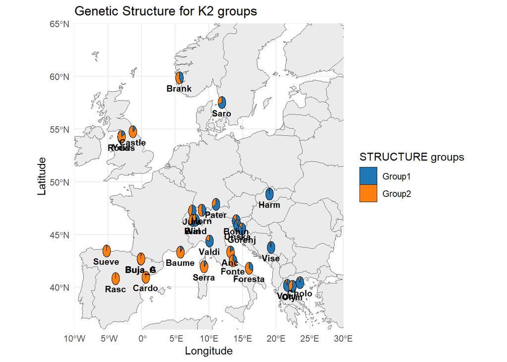

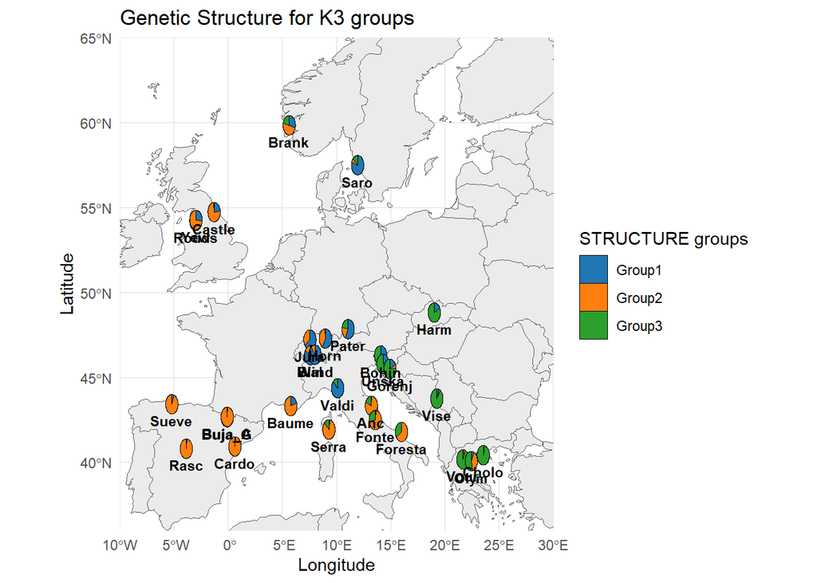

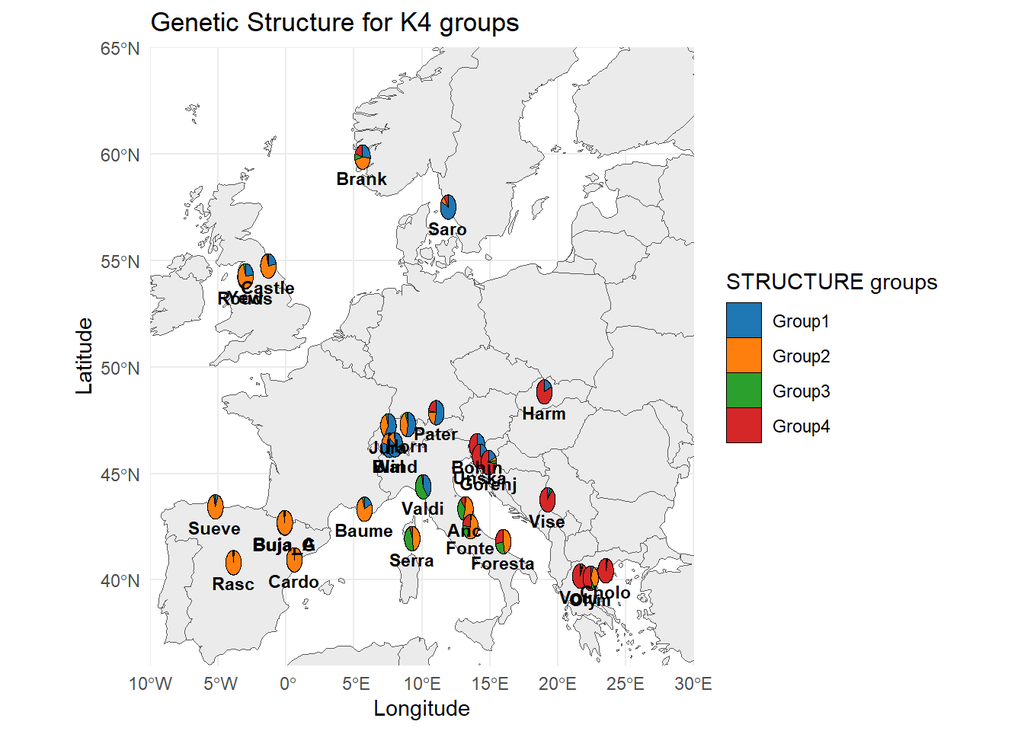

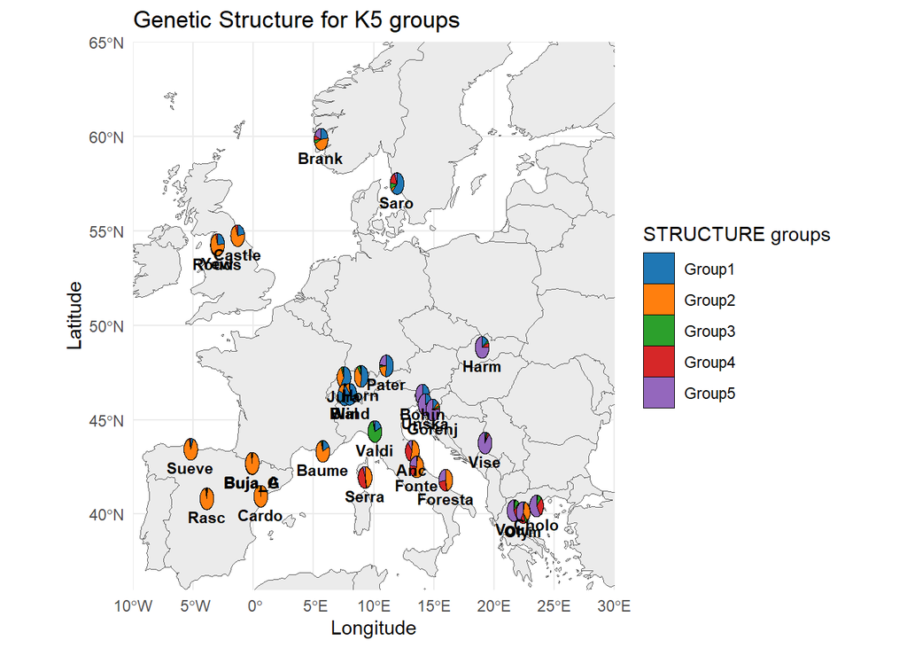

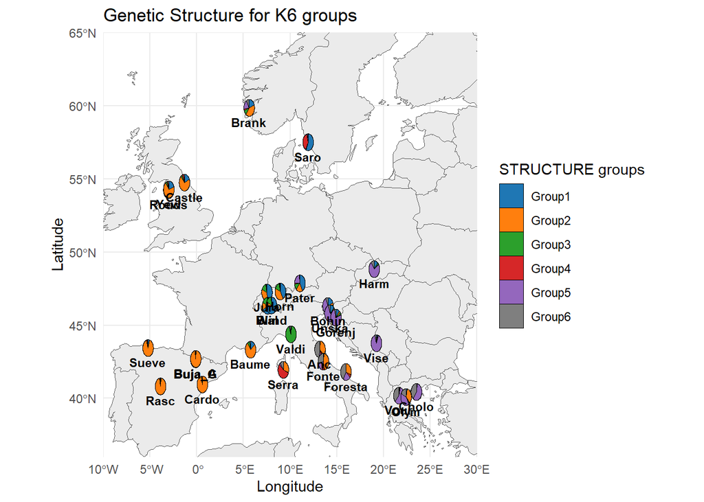

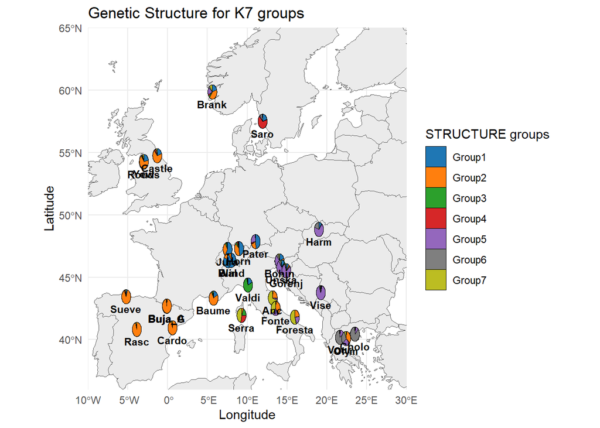

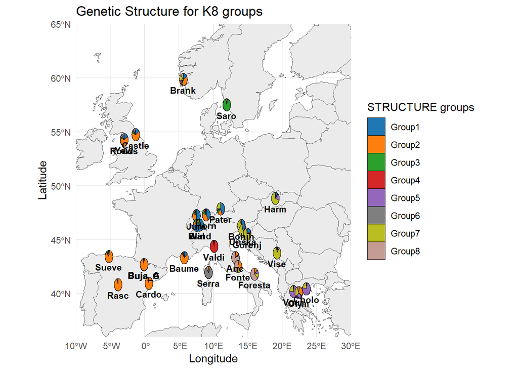

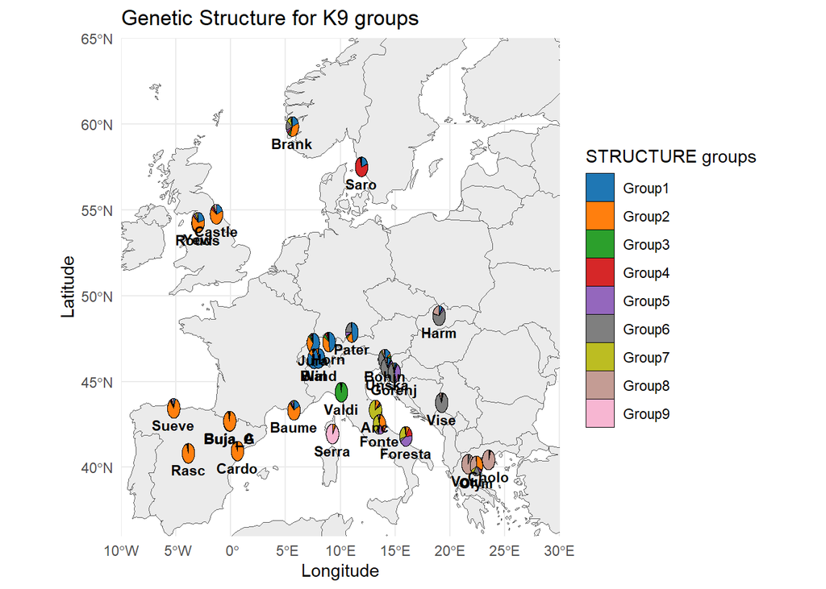

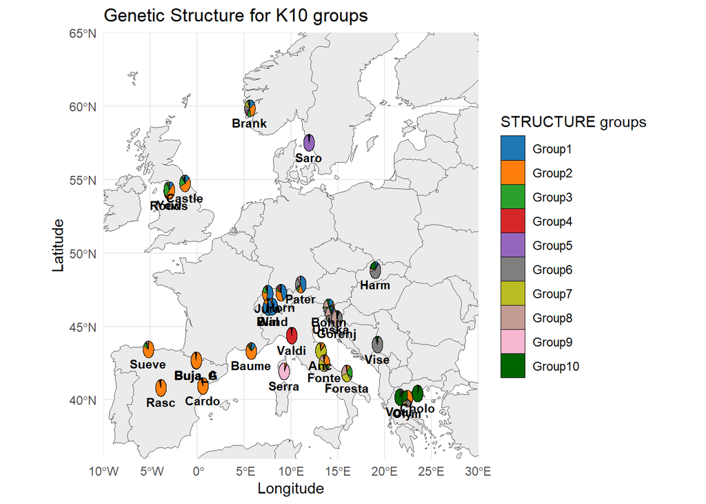

```r
for(i in 2:10){

  input <- paste0("K",i)

  data <- read.table(paste0("C:/Users/tfrancisco/Documents/Thèse/Results/species/taxus/STRUCTURE/clumpp_output/",input,"_mean.txt"))

  k_full <- data.frame(name[,c(1)],data[,-c(1:5)])
  colnames(k_full) <- c("VCF_ID", paste0("Group",6:ncol(data)-5))

  #keep consistency with the colors of the main groups
  #to do this, we will order the columns (=the groups) the same way for each K using the values of the first row.
  #Teh values of group of the first row, will order the position of the groups and then keep colors consistency along the main gene pools

  sorted_columns <- names(k_full[,-1])[order(-apply(k_full[,-1], 2, function(x) x[1]))]

# Reorder columns based on the maximum value to keep consistency with the color of the groups
k_full_bis <- k_full[, sorted_columns, drop = FALSE]

#add ID again
k_full_final <- data.frame(k_full[,1],k_full_bis);colnames(k_full_final) <- c("VCF_ID", paste0("Group",6:ncol(data)-5))


  k_with_pop <- merge(k_full_final,meta_data_vcf,"VCF_ID") %>% merge(meta_data_pop,"Population")


  k_final <- k_with_pop %>% dplyr::select(-c("Country.y","N","Elevation.DEM_90m."))

  mean_admixture_pop <- k_final %>%
   group_by(Population) %>%
  mutate(across(where(is.numeric), mean)) %>%
  slice_head(n = 1) %>%
  ungroup()

  mean_admixture_pop$Longitude=as.numeric(mean_admixture_pop$Longitude);mean_admixture_pop$Latitude=as.numeric(mean_admixture_pop$Latitude)

  mean_admixture_pop$Population_bis <- c("Anc","Blind","Bohin","Brank","Buja_A","Buja_G","Cardo","Castle","Fonte","Foresta","Gorenj","Harm","Horn","Jura","Cholo","Olym","Vour","Pater","Rasc","Rouds","Baume","Saro","Serra","Sueve","Unska","Valdi","Vise","Wal","Yew")



  groups <- paste0("Group",6:ncol(data)-5)


  admin <- ne_countries(scale = "medium", returnclass = "sf")



my.colors<- c("#1f77b4", "#ff7f0e", "#2ca02c", "#d62728", "#9467bd","#7f7f7f","#bcbd22", "#c49c94", "#f7b6d2", "darkgreen")
# Plot the map with scatterpie
map_pop <- ggplot() +
  geom_sf(data = admin, fill = gray(0.92), size = 0) +#background of the map
  geom_scatterpie(
    data = mean_admixture_pop,
    aes(x = Longitude, y = Latitude),
    cols = groups, # Adjust columns accordingly to the groups
    size = 0,#size of the bold (=gras)
    alpha = 1, #transparence
  ) +
  geom_text(
    data = mean_admixture_pop,
    aes(x = Longitude, y = Latitude, label = Population_bis,fontface = "bold"),
    size = 3, # size of the label text
    vjust = 2 # vertical justification for the label
  ) +
  scale_fill_manual(values=my.colors)+
  coord_sf(xlim = c(-10, 30), ylim = c(36, 65), expand = FALSE) +#extension of the map
  theme_minimal() +
  labs(title = paste0("Genetic Structure for"," ", input," ", "groups"),fill="STRUCTURE groups")


print(map_pop)



 #save
pdf(paste0("C:/Users/tfrancisco/Documents/Thèse/Results/species/taxus/GEA_new_var/Structure/Map_",input,"_STRUCTURE.pdf"));print(map_pop);dev.off()

}
```

Interpretation: Based on the BestK from CLUMPAK and the biological relevance, we selected K=3 and also because it explains the largest pattern of population structure. Then, we will use k=3 for imputation by imputing genomic missing data within the 3 groups.

Now, we want to save the scores for K=3 to use them potentially in variance partitioning as Population structure proxy

```r
#we need to run the function only for k=3 and save the dataframe
data <- read.table("C:/Users/tfrancisco/Documents/Thèse/Results/species/taxus/STRUCTURE/clumpp_output/K3_mean.txt")

  k_full <- data.frame(name[,c(1)],data[,-c(1:5)])
  colnames(k_full) <- c("VCF_ID", paste0("Group",6:ncol(data)-5))

  #keep consistency with the colors of the main groups
  #to do this, we will order the columns (=the groups) the same way for each K using the values of the first row.
  #The values of group of the first row, will order the position of the groups and then keep colors consistency along the main gene pools.

  sorted_columns <- names(k_full[,-1])[order(-apply(k_full[,-1], 2, function(x) x[1]))]

# Reorder columns based on the maximum value to keep consistency with the color of the groups
k_full_bis <- k_full[, sorted_columns, drop = FALSE]

#add ID again
k_full_final <- data.frame(k_full[,1],k_full_bis);colnames(k_full_final) <- c("VCF_ID", paste0("Group",6:ncol(data)-5))


  k_with_pop <- merge(k_full_final,meta_data_vcf,"VCF_ID") %>% merge(meta_data_pop,"Population")


  k_final <- k_with_pop %>% dplyr::select(-c("Country.y","N","Elevation.DEM_90m."))

  mean_admixture_pop <- k_final %>%
   group_by(Population) %>%
  mutate(across(where(is.numeric), mean)) %>%
  slice_head(n = 1) %>%
  ungroup() %>%
  mutate(across(where(is.numeric),scale))

  Cluster_score_STRUCTURE_T_Adapcon_gentree <- mean_admixture_pop[,-c(2,6:8)]

  save(Cluster_score_STRUCTURE_T_Adapcon_gentree,file="C:/Users/tfrancisco/Documents/Thèse/Data/Espèces/Taxus_baccata/GEA/Structure_proxy/Cluster_score_STRUCTURE_T_Adapcon_gentree.Rdata")
```

not using admixture anymore bu see how to do it.